# Machine Learning

Gabriela Maślanka, Karolina Gajewska

2024-01-14

### Wstęp

Celem niniejszej pracy jest osiągnięcie jak najbardziej precyzyjnej prognozy dotyczącej charakteru nowotworu piersi u kobiet, opartej na zebranych danych dotyczących zmian nowotworowych. Projekt jest zamieszczony również na GitHubie: https://github.com/G0409M/R_Machine_Learning

Biblioteki użyte w projekcie:

```r
library(tidyverse)
library(psych)
library(corrplot)
library(e1071)
library(caret)
library(randomForest)
library(ROSE)
library(smotefamily)
library(DALEX)
library(gridExtra)
```

### Opis danych

```r
data<-read.csv("Breast_cancer_data.csv", header = TRUE, sep = ",",dec = ".")
head(data)
```

```
##   mean_radius mean_texture mean_perimeter mean_area mean_smoothness diagnosis
## 1       17.99        10.38         122.80    1001.0         0.11840         0
## 2       20.57        17.77         132.90    1326.0         0.08474         0
## 3       19.69        21.25         130.00    1203.0         0.10960         0
## 4       11.42        20.38          77.58     386.1         0.14250         0
## 5       20.29        14.34         135.10    1297.0         0.10030         0
## 6       12.45        15.70          82.57     477.1         0.12780         0
```

Dane na których możemy budować nasz model to:

**zmienne objaśniające**:

**mean_radius**: Średni rozmiar guza, istotny dla oceny jego wielkości.

**mean_texture**: Jednorodność komórek guza, mierzona wartością tekstury.

**mean_perimeter**: Zewnętrzna długość krzywej guza, informująca o jego kształcie.

**mean_area**: Przestrzenny rozmiar guza, wyrażony jako średnia powierzchnia.

**mean_smoothness**: Stopień równomierności komórek, określający gładkość guza.

**Zmienna objaśniana:**

**diagnosis**: Zmienna binarna (0-1) określająca czy zmiana nowotworowa zostałą rozpoznana jako łagodna (0) czy złośliwa (1) .

##### Analiza wpływu poszczególnych zmiennych na zmienną prognozowaną

Na początku sprawdzamy, czy w naszym zbiorze danych zmienne objaśniające mają wpływ na zmienną objaśnianą. Wykorzystujemy do tego model regresji logistycznej.

```r
set.seed(1)

data$diagnosis<- as.factor(data$diagnosis)
index <- sample(nrow(data), 450, replace = F)
train <- data[index,]
test <- data[-index,]

model <- glm(diagnosis ~ mean_radius + mean_texture + mean_perimeter + mean_area + mean_smoothness,
             data,
             family = "binomial")
summary(model)
```

```
##
## Call:
## glm(formula = diagnosis ~ mean_radius + mean_texture + mean_perimeter +
##     mean_area + mean_smoothness, family = "binomial", data = data)
##
## Coefficients:
##                   Estimate Std. Error z value Pr(>|z|)
## (Intercept)       12.52617    8.38544   1.494 0.135228
## mean_radius        6.27525    1.83569   3.418 0.000630 ***
## mean_texture      -0.36410    0.06004  -6.064 1.33e-09 ***
## mean_perimeter    -0.60716    0.17944  -3.384 0.000715 ***
## mean_area         -0.04178    0.01375  -3.038 0.002378 **
## mean_smoothness -118.46210   20.64837  -5.737 9.63e-09 ***
## ---
## Signif. codes:  0 '***' 0.001 '**' 0.01 '*' 0.05 '.' 0.1 ' ' 1
##
## (Dispersion parameter for binomial family taken to be 1)
##
##     Null deviance: 751.44  on 568  degrees of freedom
## Residual deviance: 169.22  on 563  degrees of freedom
## AIC: 181.22
##
## Number of Fisher Scoring iterations: 8
```

Zauważamy, że wszystkie zmienne wpływają na wynik zmiennej objaśnianej.

Wykonujemy również macierz korelacji:

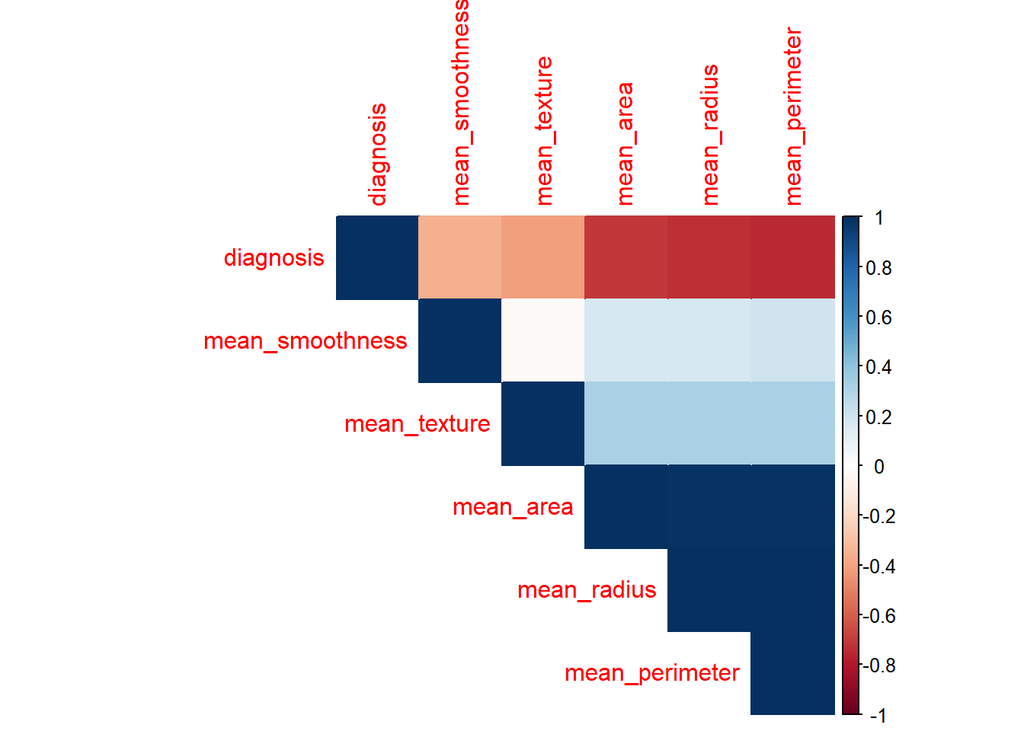

```r
data$diagnosis <- as.numeric(data$diagnosis)

correlation <- cor(data[, c("mean_radius", "mean_texture", "mean_perimeter","mean_area", "mean_smoothness", "diagnosis")])


corrplot(correlation, method = "color", type = "upper", order = "hclust")
```

```r
data$diagnosis <- as.factor(data$diagnosis)
data$diagnosis <- factor(data$diagnosis, levels = c( 1, 2), labels = c( 1, 0))
```

Najbardziej optymalna byłaby sytuacja, gdyby zmienne objaśniające były silnie skorelowane ze zmienną objaśnianą ale słabo skorelowane między sobą. Na powyższym wykresie widzimy że zmienna diagnosis jest stosunkowo silnie ujemnie skorelowana ze zmiennymi mean_area, mean_radius oraz mean_perimiter, a słabiej, choć również skorelowana ze zmiennymi mean_smoothness oraz mean_texture. Widzimy również że korelacja nie zachodzi między tymi zmiennymi. Niestety zmienne które najbardziej wpływają na zmienną objaśnianą są ze sobą skorelowane, ale z racji iż posiadamy niewielką ilość zmiennych objaśniających nie będziemy ich usuwać.

##### Podstawowe statystyki na zbiorze danych i ocena zbalansowania zbioru danych

```r
describe(select(data, -diagnosis))
```

```
##                 vars   n   mean     sd median trimmed    mad    min     max
## mean_radius        1 569  14.13   3.52  13.37   13.82   2.82   6.98   28.11
## mean_texture       2 569  19.29   4.30  18.84   19.04   4.17   9.71   39.28
## mean_perimeter     3 569  91.97  24.30  86.24   89.74  18.84  43.79  188.50
## mean_area          4 569 654.89 351.91 551.10  606.13 227.28 143.50 2501.00
## mean_smoothness    5 569   0.10   0.01   0.10    0.10   0.01   0.05    0.16
##                   range skew kurtosis    se
## mean_radius       21.13 0.94     0.81  0.15
## mean_texture      29.57 0.65     0.73  0.18
## mean_perimeter   144.71 0.99     0.94  1.02
## mean_area       2357.50 1.64     3.59 14.75
## mean_smoothness    0.11 0.45     0.82  0.00
```

```r
prop.table(table(data$diagnosis))
```

```
##
##         1         0
## 0.3725835 0.6274165
```

**mean_radius (Średnica guza)**:

Średnia średnicy guza wynosi 14.13, a odchylenie standardowe wynosi 3.52. Sugeruje to umiarkowany stopień zmienności w średnicy guza. Mediana wynosi 13.37, a średnia przycięta (bez wpływu wartości skrajnych) to 13.82, co wskazuje na ewentualne obecność wartości odstających, jednakże nie powinno być ich bardzo dużo bo mediana i średnia są do siebie zbliżone, co sugeruje również że rozkład tej zmiennej może być zbliżony do rozkładu normalnego.

**mean_texture (Średnia tekstura guza):**

Średnia tekstury guza wynosi 19.29, a odchylenie standardowe to 4.30. Rozproszenie jest względnie wysokie. Mediana (18.84) i średnia przycięta (19.04) są zbliżone, co sugeruje równomierny rozkład wartości jak i również możliwość istnienia kilku wartości odstających.

**mean_perimeter (Średni obwód guza):**

Średni obwód guza wynosi 91.97, a odchylenie standardowe wynosi 24.30, co wskazuje na duże zróżnicowanie w obwodzie guza. Mediana (86.24) i średnia przycięta (89.74) są niższe niż średnia arytmetyczna, co może świadczyć o wpływie wartości skrajnych.

**mean_area (Średnia powierzchnia guza):**

Średnia powierzchnia guza wynosi 654.89, a odchylenie standardowe to 351.91, co sugeruje znaczną zmienność. Mediana (551.10) jest znacząco niższa niż średnia arytmetyczna, co może wynikać z obecności wartości odstających o dużych powierzchniach guza. Zmienna ta wydaje się być znacznie bardziej zróżnicowana niż pozostałe zmienne, co sugeruje, że obszar guzów może mieć znaczący wpływ na analizę.

**mean_smoothness (Średnia gładkość guza):**

Średnia gładkość guza wynosi 0.10, a odchylenie standardowe to 0.01. Wartości te sugerują niewielką zmienność w gładkości guza. Skośność jest bliska zeru, co wskazuje na symetryczny rozkład. Wartości “mean_smoothness” wydają się być dość zbliżone, co wskazuje na mniejszą zmienność w gładkości guza.

#### Przygotowanie danych

W celu przygotowania danych sprawdzamy, czy występują braki danych.

```r
any(is.na(data))
```

```
## [1] FALSE
```

W zbiorze danych nie posiadamy braków.

Następnie wykonujemy wykresy pudełkowe aby sprawdzić, czy zmienne zawierają wartości odstające.

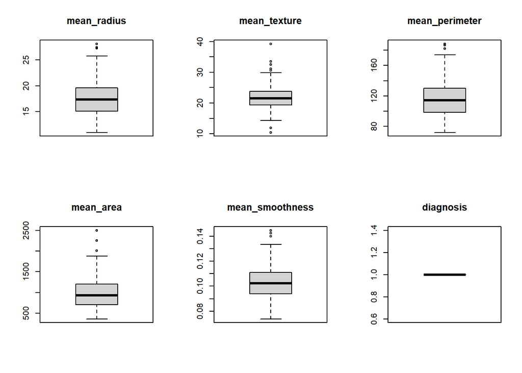

```r
data_positive <- data[data$diagnosis==1,]
data_negative <- data[data$diagnosis==0,]
par(mfrow = c(2, 3))
for (nazwa_zmiennej in colnames(data_positive)) {
  boxplot(data_positive[[nazwa_zmiennej]], main = nazwa_zmiennej)
}
```

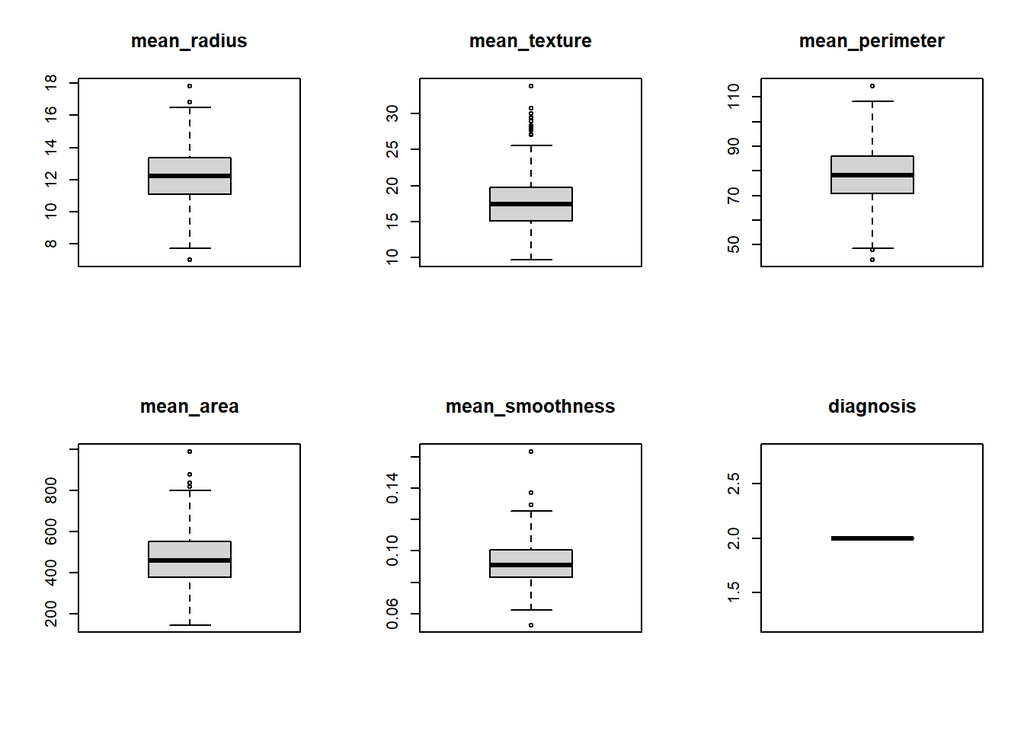

```r
for (nazwa_zmiennej in colnames(data_negative)) {
  boxplot(data_negative[[nazwa_zmiennej]], main = nazwa_zmiennej)
}
```

```r
par(mfrow = c(1, 1))
```

##### Usuwanie wartości odstających

```r
usuń_odstające <- function(dane) {
  for (nazwa_zmiennej in colnames(dane)) {
    if (nazwa_zmiennej != "diagnosis") {  # Sprawdzenie, czy kolumna nie jest "diagnosis"
      Q1 <- quantile(dane[[nazwa_zmiennej]], 0.25)
      Q3 <- quantile(dane[[nazwa_zmiennej]], 0.75)
      IQR_value <- Q3 - Q1

      # Określenie granic wartości odstających
      dolna_granica <- Q1 - 1.5 * IQR_value
      gorna_granica <- Q3 + 1.5 * IQR_value

      # Usunięcie wartości odstających
      dane <- dane[!(dane[[nazwa_zmiennej]] < dolna_granica | dane[[nazwa_zmiennej]] > gorna_granica), ]
    }
  }
  return(dane)
}

data_positive_clear<- usuń_odstające(data_positive)
data_negative_clear<- usuń_odstające(data_negative)
data_clear <- rbind(data_positive_clear, data_negative_clear)
```

#### Podział na zbiór uczący oraz testowy

```r
index <- sample(nrow(data), 420, replace = F)
train <- data[index,]
test <- data[-index,]
```

Następnie porównujemy podstawowe statystyki w obu grupach.

```r
describe(select(train, -diagnosis))
```

```
##                 vars   n   mean     sd median trimmed    mad    min     max
## mean_radius        1 420  13.95   3.41  13.09   13.64   2.65   6.98   28.11
## mean_texture       2 420  18.95   4.12  18.59   18.72   4.15   9.71   32.47
## mean_perimeter     3 420  90.65  23.46  84.72   88.43  18.06  43.79  188.50
## mean_area          4 420 636.67 338.75 528.30  588.58 208.60 143.50 2501.00
## mean_smoothness    5 420   0.10   0.01   0.10    0.10   0.01   0.05    0.16
##                   range skew kurtosis    se
## mean_radius       21.13 0.98     0.97  0.17
## mean_texture      22.76 0.50     0.05  0.20
## mean_perimeter   144.71 1.03     1.13  1.14
## mean_area       2357.50 1.75     4.45 16.53
## mean_smoothness    0.11 0.50     1.10  0.00
```

```r
prop.table(table(train$diagnosis))
```

```
##
##         1         0
## 0.3357143 0.6642857
```

```r
describe(select(test, -diagnosis))
```

```
##                 vars   n   mean     sd median trimmed    mad    min     max
## mean_radius        1 149  14.63   3.79  13.81   14.34   3.29   7.69   27.22
## mean_texture       2 149  20.25   4.67  19.82   19.94   4.36  10.72   39.28
## mean_perimeter     3 149  95.68  26.24  90.30   93.44  22.98  48.34  182.10
## mean_area          4 149 706.24 383.18 592.60  656.29 281.69 170.40 2250.00
## mean_smoothness    5 149   0.10   0.01   0.10    0.10   0.01   0.06    0.14
##                   range skew kurtosis    se
## mean_radius       19.53 0.79     0.36  0.31
## mean_texture      28.56 0.82     1.35  0.38
## mean_perimeter   133.76 0.82     0.41  2.15
## mean_area       2079.60 1.35     1.86 31.39
## mean_smoothness    0.07 0.33    -0.05  0.00
```

```r
prop.table(table(test$diagnosis))
```

```
##
##         1         0
## 0.4765101 0.5234899
```

##### Standaryzujemy dane

```r
train_glm<-train
train$mean_radius<- scale(train$mean_radius)
train$mean_texture<- scale(train$mean_texture)
train$mean_perimeter<- scale(train$mean_perimeter)
train$mean_area<- scale(train$mean_area)
train$mean_smoothness<- scale(train$mean_smoothness)

test_glm<- test
test$mean_radius<- scale(test$mean_radius)
test$mean_texture<- scale(test$mean_texture)
test$mean_perimeter<- scale(test$mean_perimeter)
test$mean_area<- scale(test$mean_area)
test$mean_smoothness<- scale(test$mean_smoothness)
```

#### Wykonanie modeli uczenia maszynowego

##### Model SVM

Pierwszym modelem, któy zdecydowałyśmy się stworzyć jest model SVM o jądrze liniowym. Jedynym parametrem, jaki można w tym modelu optymalizować to wartość kosztu, dlatego wykonałyśmy wykres obrazujący wartości dokładności i czułości w zależności od przyjętego poziomu kosztu.

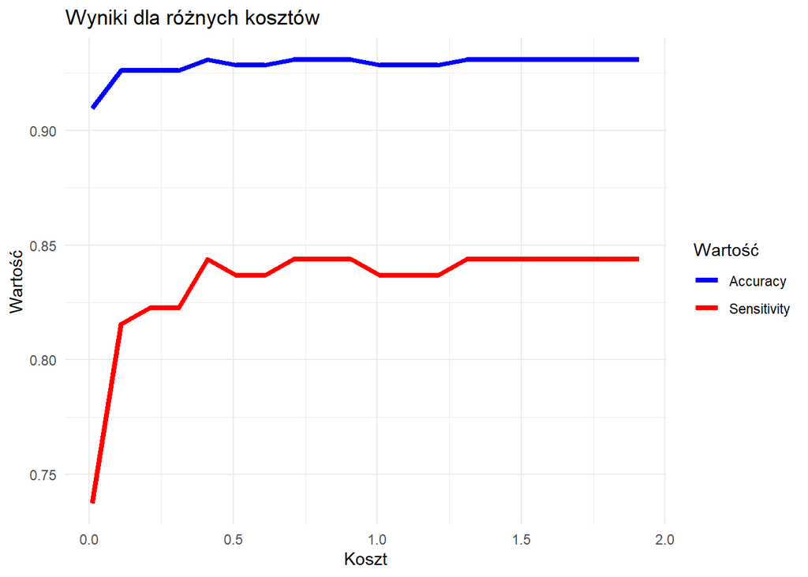

```r
library(ggplot2)

costs <- seq(0.01, 2, by = 0.1)
results <- data.frame(cost = numeric(), accuracy = numeric(), sensitivity = numeric())

for (cost in costs) {
  model <- svm(formula = diagnosis ~ ., data = train, kernel = "linear", cost = cost)
  pred_train <- predict(model, newdata = train)
  conf_matrix <- confusionMatrix(pred_train, train$diagnosis, positive = "1")
  accuracy <- conf_matrix$overall["Accuracy"]
  sensitivity <- conf_matrix$byClass["Sensitivity"]
  results <- rbind(results, data.frame(cost = cost, accuracy = accuracy, sensitivity = sensitivity))
}

ggplot(results, aes(x = cost)) +
  geom_line(aes(y = accuracy, color = "Accuracy"), size = 1.5) +
  geom_line(aes(y = sensitivity, color = "Sensitivity"), size = 1.5) +
  labs(title = "Wyniki dla różnych kosztów",
       x = "Koszt", y = "Wartość") +
  scale_color_manual(name = "Wartość", values = c("Accuracy" = "blue", "Sensitivity" = "red")) +
  theme_minimal()
```

Po analizie wykresu zdecydowaliśmy się przyjąć wartość parametru kosztu na poziomie 0.41 ponieważ oferuje on dobry stosunek dokładności do czułości.

Następnie tworzymy model SVM z przyjętą wartością parametru kosztu oraz porównujemny wyniki na zbiorze uczącym i testowym

```r
model <- svm(formula = diagnosis ~ ., data = train, kernel = "linear", cost = 0.41)
pred_train <- predict(model, newdata = train)
conf_matrix_train <- confusionMatrix(pred_train, train$diagnosis, positive = "1")
accuracy_train <- conf_matrix_train$overall["Accuracy"]
sensitivity_train <- conf_matrix_train$byClass["Sensitivity"]
specificity_train <- conf_matrix_train$byClass["Specificity"]

pred_test <- predict(model, newdata = test)
conf_matrix_test <- confusionMatrix(pred_test, test$diagnosis, positive = "1")
accuracy_test <- conf_matrix_test$overall["Accuracy"]
sensitivity_test <- conf_matrix_test$byClass["Sensitivity"]
specificity_test <- conf_matrix_test$byClass["Specificity"]

comparison_table_svm <- data.frame(
  Dataset = c("Train", "Test"),
  Accuracy = c(accuracy_train, accuracy_test),
  Sensitivity = c(sensitivity_train, sensitivity_test),
  Specificity = c(specificity_train, specificity_test)
)

print(comparison_table_svm)
```

```
##   Dataset  Accuracy Sensitivity Specificity
## 1   Train 0.9309524   0.8439716   0.9749104
## 2    Test 0.8859060   0.7746479   0.9871795
```

Dla porónania wykonamy oversampling i undersampling, aby sprawdzić czy model będzie wtedy lepszy.

Undersampling:

```r
model <- svm(formula = diagnosis ~ ., data = under_train, kernel = "linear", cost = 0.41)
pred_train <- predict(model, newdata = under_train)
conf_matrix_train <- confusionMatrix(pred_train, under_train$diagnosis, positive = "1")
accuracy_train <- conf_matrix_train$overall["Accuracy"]
sensitivity_train <- conf_matrix_train$byClass["Sensitivity"]
specificity_train <- conf_matrix_train$byClass["Specificity"]

pred_test <- predict(model, newdata = test)
conf_matrix_test <- confusionMatrix(pred_test, test$diagnosis, positive = "1")
accuracy_test <- conf_matrix_test$overall["Accuracy"]
sensitivity_test <- conf_matrix_test$byClass["Sensitivity"]
specificity_test <- conf_matrix_test$byClass["Specificity"]

comparison_table_svm_u <- data.frame(
  Dataset = c("Train", "Test"),
  Accuracy = c(accuracy_train, accuracy_test),
  Sensitivity = c(sensitivity_train, sensitivity_test),
  Specificity = c(specificity_train, specificity_test)
)

print(comparison_table_svm_u)
```

```
##   Dataset  Accuracy Sensitivity Specificity
## 1   Train 0.9290780   0.9290780   0.9290780
## 2    Test 0.9328859   0.9014085   0.9615385
```

Oversampling:

```r
model <- svm(formula = diagnosis ~ ., data = over_train, kernel = "linear", cost = 0.41)
pred_train <- predict(model, newdata = over_train)
conf_matrix_train <- confusionMatrix(pred_train, over_train$diagnosis, positive = "1")
accuracy_train <- conf_matrix_train$overall["Accuracy"]
sensitivity_train <- conf_matrix_train$byClass["Sensitivity"]
specificity_train <- conf_matrix_train$byClass["Specificity"]

pred_test <- predict(model, newdata = test)
conf_matrix_test <- confusionMatrix(pred_test, test$diagnosis, positive = "1")
accuracy_test <- conf_matrix_test$overall["Accuracy"]
sensitivity_test <- conf_matrix_test$byClass["Sensitivity"]
specificity_test <- conf_matrix_test$byClass["Specificity"]

comparison_table_svm_o <- data.frame(
  Dataset = c("Train", "Test"),
  Accuracy = c(accuracy_train, accuracy_test),
  Sensitivity = c(sensitivity_train, sensitivity_test),
  Specificity = c(specificity_train, specificity_test)
)

print(comparison_table_svm_o)
```

```
##   Dataset  Accuracy Sensitivity Specificity
## 1   Train 0.9175824   0.9176030   0.9175627
## 2    Test 0.9127517   0.8591549   0.9615385
```

```r
print(comparison_table_svm)
```

```
##   Dataset  Accuracy Sensitivity Specificity
## 1   Train 0.9309524   0.8439716   0.9749104
## 2    Test 0.8859060   0.7746479   0.9871795
```

```r
print(comparison_table_svm_u)
```

```
##   Dataset  Accuracy Sensitivity Specificity
## 1   Train 0.9290780   0.9290780   0.9290780
## 2    Test 0.9328859   0.9014085   0.9615385
```

```r
print(comparison_table_svm_o)
```

```
##   Dataset  Accuracy Sensitivity Specificity
## 1   Train 0.9175824   0.9176030   0.9175627
## 2    Test 0.9127517   0.8591549   0.9615385
```

```r
choosen_svm<- comparison_table_svm_o
```

##### Lasy losowe

```r
model <- randomForest(diagnosis ~ ., data = train%>%slice_sample(prop=0.4), ntree = 100)
pred_train <- predict(model, newdata = train)
conf_matrix_train <- confusionMatrix(pred_train, train$diagnosis, positive = "1")
accuracy_train <- conf_matrix_train$overall["Accuracy"]
sensitivity_train <- conf_matrix_train$byClass["Sensitivity"]
specificity_train <- conf_matrix_train$byClass["Specificity"]

pred_test <- predict(model, newdata = test)
conf_matrix_test <- confusionMatrix(pred_test, test$diagnosis, positive = "1")
accuracy_test <- conf_matrix_test$overall["Accuracy"]
sensitivity_test <- conf_matrix_test$byClass["Sensitivity"]
specificity_test <- conf_matrix_test$byClass["Specificity"]

comparison_table_rForest <- data.frame(
  Dataset = c("Train", "Test"),
  Accuracy = c(accuracy_train, accuracy_test),
  Sensitivity = c(sensitivity_train, sensitivity_test),
  Specificity = c(specificity_train, specificity_test)
)

print(comparison_table_rForest)
```

```
##   Dataset  Accuracy Sensitivity Specificity
## 1   Train 0.9452381   0.8794326   0.9784946
## 2    Test 0.8724832   0.7464789   0.9871795
```

Dla porónania wykonamy oversampling, aby sprawdzić czy model będzie wtedy lepszy.

Undersampling:

```r
model <- randomForest(diagnosis ~ ., data = under_train%>%slice_sample(prop=0.4), ntree = 100)
pred_train <- predict(model, newdata = under_train)
conf_matrix_train <- confusionMatrix(pred_train, under_train$diagnosis, positive = "1")
accuracy_train <- conf_matrix_train$overall["Accuracy"]
sensitivity_train <- conf_matrix_train$byClass["Sensitivity"]
specificity_train <- conf_matrix_train$byClass["Specificity"]

pred_test <- predict(model, newdata = test)
conf_matrix_test <- confusionMatrix(pred_test, test$diagnosis, positive = "1")
accuracy_test <- conf_matrix_test$overall["Accuracy"]
sensitivity_test <- conf_matrix_test$byClass["Sensitivity"]
specificity_test <- conf_matrix_test$byClass["Specificity"]

comparison_table_rForest_u <- data.frame(
  Dataset = c("Train", "Test"),
  Accuracy = c(accuracy_train, accuracy_test),
  Sensitivity = c(sensitivity_train, sensitivity_test),
  Specificity = c(specificity_train, specificity_test)
)

print(comparison_table_rForest_u)
```

```
##   Dataset  Accuracy Sensitivity Specificity
## 1   Train 0.9290780   0.9716312   0.8865248
## 2    Test 0.9194631   0.9014085   0.9358974
```

Oversampling:

```r
model <- randomForest(diagnosis ~ ., data = over_train%>%slice_sample(prop=0.4), ntree = 100)
pred_train <- predict(model, newdata = over_train)
conf_matrix_train <- confusionMatrix(pred_train, over_train$diagnosis, positive = "1")
accuracy_train <- conf_matrix_train$overall["Accuracy"]
sensitivity_train <- conf_matrix_train$byClass["Sensitivity"]
specificity_train <- conf_matrix_train$byClass["Specificity"]

pred_test <- predict(model, newdata = test)
conf_matrix_test <- confusionMatrix(pred_test, test$diagnosis, positive = "1")
accuracy_test <- conf_matrix_test$overall["Accuracy"]
sensitivity_test <- conf_matrix_test$byClass["Sensitivity"]
specificity_test <- conf_matrix_test$byClass["Specificity"]

comparison_table_rForest_o <- data.frame(
  Dataset = c("Train", "Test"),
  Accuracy = c(accuracy_train, accuracy_test),
  Sensitivity = c(sensitivity_train, sensitivity_test),
  Specificity = c(specificity_train, specificity_test)
)

print(comparison_table_rForest_o)
```

```
##   Dataset  Accuracy Sensitivity Specificity
## 1   Train 0.9578755   0.9625468    0.953405
## 2    Test 0.9060403   0.8309859    0.974359
```

Porównamy wyniki uzyskane z lasów losowych oraz lasów losowych z zastosowaniem oversamplingu i undersamplingu.

```r
print(comparison_table_rForest)
```

```
##   Dataset  Accuracy Sensitivity Specificity
## 1   Train 0.9452381   0.8794326   0.9784946
## 2    Test 0.8724832   0.7464789   0.9871795
```

```r
print(comparison_table_rForest_u)
```

```
##   Dataset  Accuracy Sensitivity Specificity
## 1   Train 0.9290780   0.9716312   0.8865248
## 2    Test 0.9194631   0.9014085   0.9358974
```

```r
print(comparison_table_rForest_o)
```

```
##   Dataset  Accuracy Sensitivity Specificity
## 1   Train 0.9578755   0.9625468    0.953405
## 2    Test 0.9060403   0.8309859    0.974359
```

```r
choosen_rForest<- comparison_table_rForest_u
```

##### Model regersji logistycznej

Ostatnim modelem utworzonym w nasym projekcie będzie model regresji logistycznej

```r
model<- caret::train(diagnosis ~ ., data = train_glm, method = "glm")
```

```r
summary(model)
```

```
##
## Call:
## NULL
##
## Coefficients:
##                   Estimate Std. Error z value Pr(>|z|)
## (Intercept)       18.19933    9.75856   1.865  0.06219 .
## mean_radius        5.38037    2.09861   2.564  0.01035 *
## mean_texture      -0.41639    0.07512  -5.543 2.97e-08 ***
## mean_perimeter    -0.57144    0.20810  -2.746  0.00603 **
## mean_area         -0.03352    0.01495  -2.242  0.02496 *
## mean_smoothness -123.01404   23.83292  -5.162 2.45e-07 ***
## ---
## Signif. codes:  0 '***' 0.001 '**' 0.01 '*' 0.05 '.' 0.1 ' ' 1
##
## (Dispersion parameter for binomial family taken to be 1)
##
##     Null deviance: 536.05  on 419  degrees of freedom
## Residual deviance: 130.52  on 414  degrees of freedom
## AIC: 142.52
##
## Number of Fisher Scoring iterations: 8
```

```r
pred_train <- predict(model, newdata = train_glm)
conf_matrix_train <- confusionMatrix(pred_train, train_glm$diagnosis, positive = "1")
accuracy_train <- conf_matrix_train$overall["Accuracy"]
sensitivity_train <- conf_matrix_train$byClass["Sensitivity"]
specificity_train <- conf_matrix_train$byClass["Specificity"]

pred_test <- predict(model, newdata = test_glm)
conf_matrix_test <- confusionMatrix(pred_test, test_glm$diagnosis, positive = "1")
accuracy_test <- conf_matrix_test$overall["Accuracy"]
sensitivity_test <- conf_matrix_test$byClass["Sensitivity"]
specificity_test <- conf_matrix_test$byClass["Specificity"]

comparison_table_glm <- data.frame(
  Dataset = c("Train", "Test"),
  Accuracy = c(accuracy_train, accuracy_test),
  Sensitivity = c(sensitivity_train, sensitivity_test),
  Specificity = c(specificity_train, specificity_test)
)

print(comparison_table_glm)
```

```
##   Dataset  Accuracy Sensitivity Specificity
## 1   Train 0.9452381   0.8865248   0.9749104
## 2    Test 0.9328859   0.9295775   0.9358974
```

Porównamy również, jak model regresji logistycznej działa na danych na zbiorze testowym rozszerzonym przez undersampling i oversampling.

Oversampling:

```r
model<- caret::train(diagnosis ~ ., data = over_train_glm, method = "glm")
pred_train <- predict(model, newdata = over_train_glm)
conf_matrix_train <- confusionMatrix(pred_train, over_train_glm$diagnosis, positive = "1")
accuracy_train <- conf_matrix_train$overall["Accuracy"]
sensitivity_train <- conf_matrix_train$byClass["Sensitivity"]
specificity_train <- conf_matrix_train$byClass["Specificity"]

pred_test <- predict(model, newdata = test_glm)
conf_matrix_test <- confusionMatrix(pred_test, test_glm$diagnosis, positive = "1")
accuracy_test <- conf_matrix_test$overall["Accuracy"]
sensitivity_test <- conf_matrix_test$byClass["Sensitivity"]
specificity_test <- conf_matrix_test$byClass["Specificity"]

comparison_table_glm_o <- data.frame(
  Dataset = c("Train", "Test"),
  Accuracy = c(accuracy_train, accuracy_test),
  Sensitivity = c(sensitivity_train, sensitivity_test),
  Specificity = c(specificity_train, specificity_test)
)

print(comparison_table_glm_o)
```

```
##   Dataset  Accuracy Sensitivity Specificity
## 1   Train 0.9047619   0.8888889   0.9211470
## 2    Test 0.9395973   0.9718310   0.9102564
```

Undersampling:

```r
model<- caret::train(diagnosis ~ ., data = under_train_glm, method = "glm")
pred_train <- predict(model, newdata = under_train_glm)
conf_matrix_train <- confusionMatrix(pred_train, under_train_glm$diagnosis, positive = "1")
accuracy_train <- conf_matrix_train$overall["Accuracy"]
sensitivity_train <- conf_matrix_train$byClass["Sensitivity"]
specificity_train <- conf_matrix_train$byClass["Specificity"]

pred_test <- predict(model, newdata = test_glm)
conf_matrix_test <- confusionMatrix(pred_test, test_glm$diagnosis, positive = "1")
accuracy_test <- conf_matrix_test$overall["Accuracy"]
sensitivity_test <- conf_matrix_test$byClass["Sensitivity"]
specificity_test <- conf_matrix_test$byClass["Specificity"]

comparison_table_glm_u <- data.frame(
  Dataset = c("Train", "Test"),
  Accuracy = c(accuracy_train, accuracy_test),
  Sensitivity = c(sensitivity_train, sensitivity_test),
  Specificity = c(specificity_train, specificity_test)
)

print(comparison_table_glm_u)
```

```
##   Dataset  Accuracy Sensitivity Specificity
## 1   Train 0.9391635   0.9432624   0.9344262
## 2    Test 0.9463087   0.9859155   0.9102564
```

Porównamy wyniki uzyskane z modelu opartego na regresji logistycznej oraz z zastosowaniem oversamplingu i undersamplingu.

```r
print(comparison_table_glm)
```

```
##   Dataset  Accuracy Sensitivity Specificity
## 1   Train 0.9452381   0.8865248   0.9749104
## 2    Test 0.9328859   0.9295775   0.9358974
```

```r
print(comparison_table_glm_u)
```

```
##   Dataset  Accuracy Sensitivity Specificity
## 1   Train 0.9391635   0.9432624   0.9344262
## 2    Test 0.9463087   0.9859155   0.9102564
```

```r
print(comparison_table_glm_o)
```

```
##   Dataset  Accuracy Sensitivity Specificity
## 1   Train 0.9047619   0.8888889   0.9211470
## 2    Test 0.9395973   0.9718310   0.9102564
```

```r
choosen_glm<-comparison_table_glm_u
```

### Porównanie trzech modeli:

```r
cat("Model SVM z użyciem metody oversampling")
```

```
## Model SVM z użyciem metody oversampling
```

```r
print(choosen_svm)
```

```
##   Dataset  Accuracy Sensitivity Specificity
## 1   Train 0.9175824   0.9176030   0.9175627
## 2    Test 0.9127517   0.8591549   0.9615385
```

```r
cat("Model Random Forest z użyciem metody undesampling")
```

```
## Model Random Forest z użyciem metody undesampling
```

```r
print(choosen_rForest)
```

```
##   Dataset  Accuracy Sensitivity Specificity
## 1   Train 0.9290780   0.9716312   0.8865248
## 2    Test 0.9194631   0.9014085   0.9358974
```

```r
cat("Model Regresji Logistycznej z użyciem metody undesampling")
```

```
## Model Regresji Logistycznej z użyciem metody undesampling
```

```r
print(choosen_glm)
```

```
##   Dataset  Accuracy Sensitivity Specificity
## 1   Train 0.9391635   0.9432624   0.9344262
## 2    Test 0.9463087   0.9859155   0.9102564
```

Do wykonania analizy interpretowalności wybrałyśmy model regresji logistycznej, ponieważ do jego wykonania nie musimy standaryzować danych, co ułatwia interpretowlność modelu.

### Profile ceteris-paribus (PCP)

Na początku przypominamy wygląd naszych danych.

```r
head(train_glm)
```

```
##     mean_radius mean_texture mean_perimeter mean_area mean_smoothness diagnosis
## 494       12.46        12.83          78.83     477.3         0.07372         0
## 166       14.97        19.76          95.50     690.2         0.08421         0
## 435       14.86        16.94          94.89     673.7         0.08924         0
## 116       11.93        21.53          76.53     438.6         0.09768         0
## 192       12.77        21.41          82.02     507.4         0.08749         0
## 85        12.00        15.65          76.95     443.3         0.09723         0
```

```r
model<- caret::train(diagnosis ~ ., data = train_glm, method = "glm")
explain_glm <- explain(model = model,
                       data = train_glm[,-6],
                       y = train_glm$diagnosis,
                       type = "classification",
                       label = "Logistic regression")
```

[output not shown]

```r
exp<- train_glm[108,]
exp
```

```
##     mean_radius mean_texture mean_perimeter mean_area mean_smoothness diagnosis
## 133       16.16        21.54          106.2     809.8          0.1008         1
```

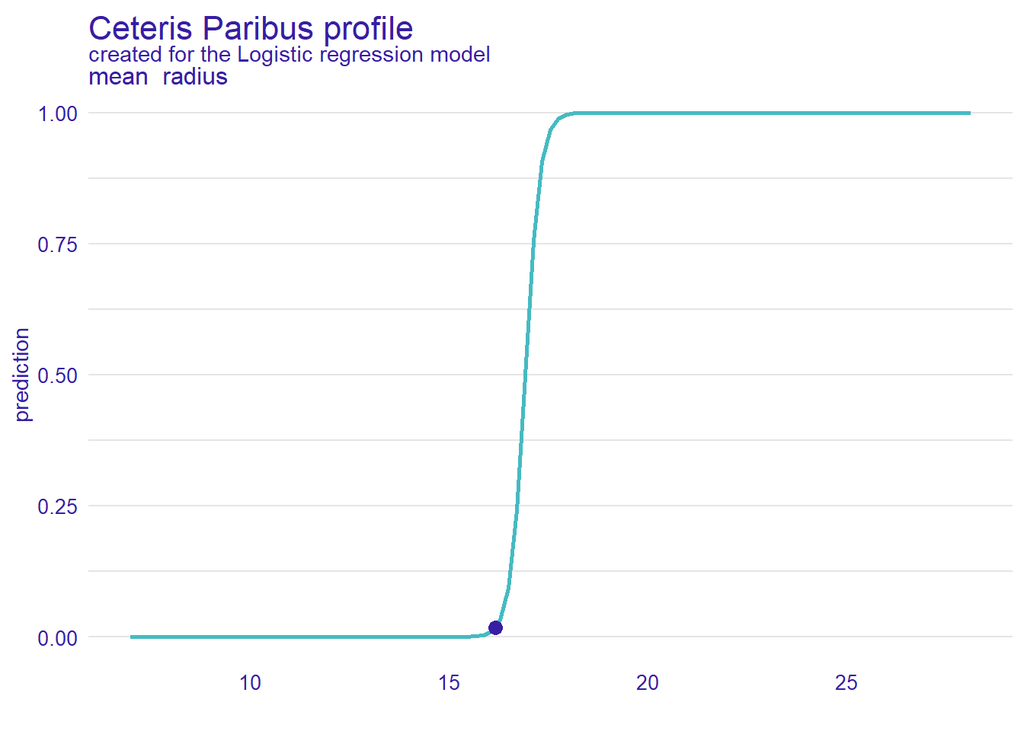

```r
pcp<- predict_profile(explain_glm, exp)
plot(pcp, variables = c("mean_radius"))
```

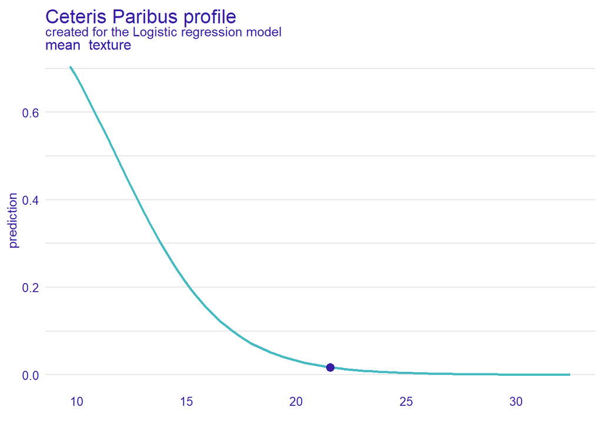

```r
plot(pcp, variables = c("mean_texture"))
```

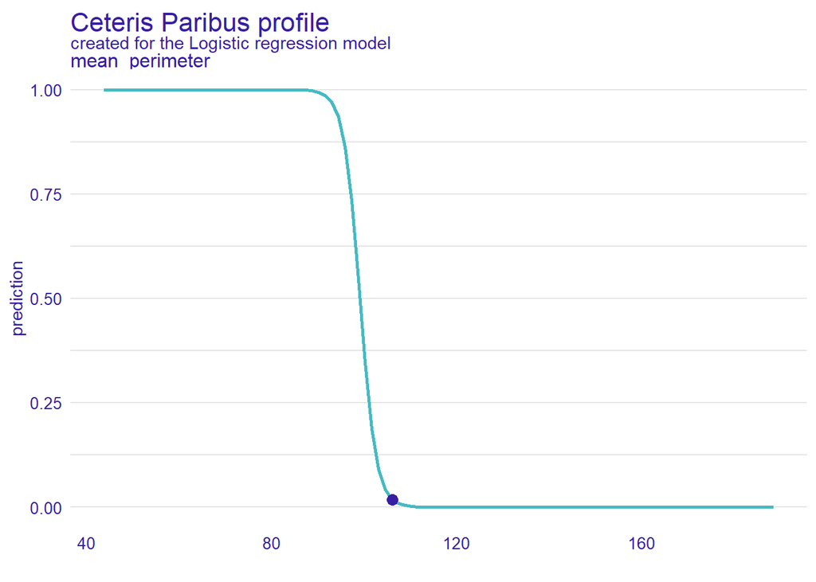

```r
plot(pcp, variables = c("mean_perimeter"))
```

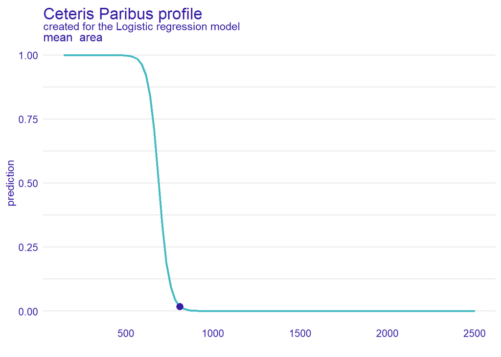

```r
plot(pcp, variables = c("mean_area"))
```

W przypadku powierzchni równiez im mniejsza tym większa szansa zachorowania na raka złolśliwego. Nasz obiekt ma niecałe 810 i jego prawdopodobieństwo jest praktycznie zerowe.

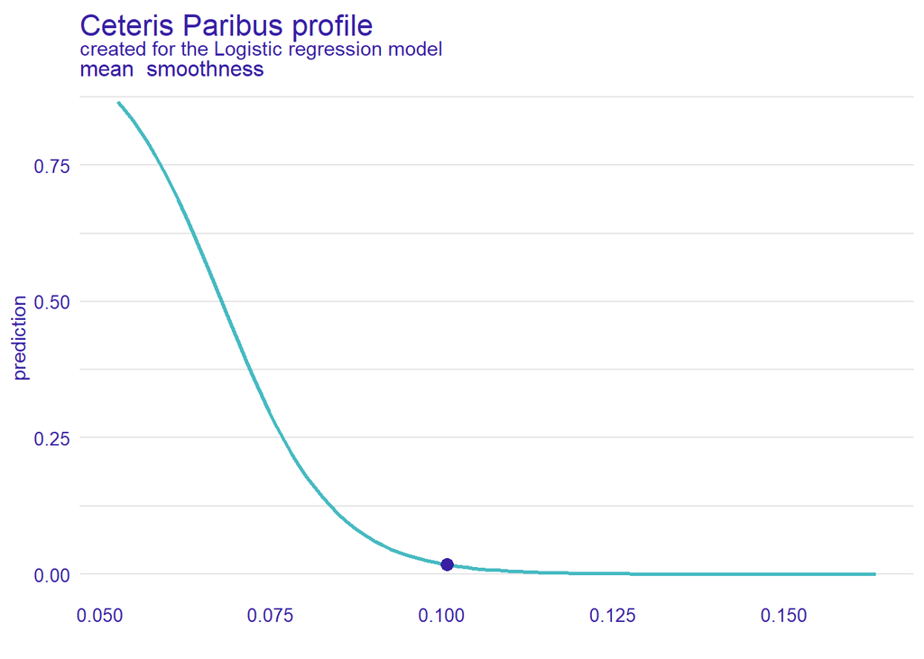

```r
plot(pcp, variables = c("mean_smoothness"))
```

Jeśli chodzi o gładkośc to dla naszego obiektu pradowpodobieństwo zachorowania na raka złośliwego równiez jest bardzo bliskie 0.

### Wykresy częściowej zależności (PDP)

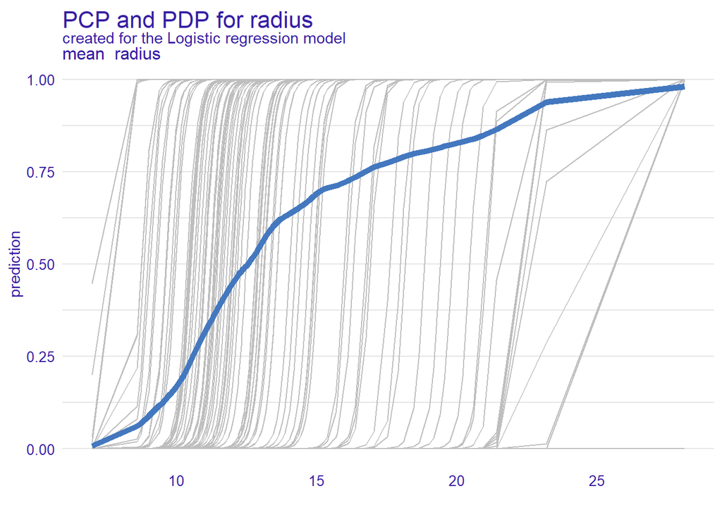

```r
pdp<- model_profile(explain_glm, "mean_radius")
plot(pdp, geom = "profiles") +
    ggtitle("PCP and PDP for radius")
```

Szare linie to PCP, które przedstawiają, jak predykcje zmieniają się dla różnych instancji danych. Niebieska linia PDP, która pokazuje średnią tendencję predykcji w zależności od promienia. Wykres ten ilustruje, jak promień wpływa na predykcje modelu regresji logistycznej dotyczące średnicy guza. Widać, że wykreś średnio rośnie jednostajnie i wraz z większym promieniem - rośnie prawdopdobieństwo choroby

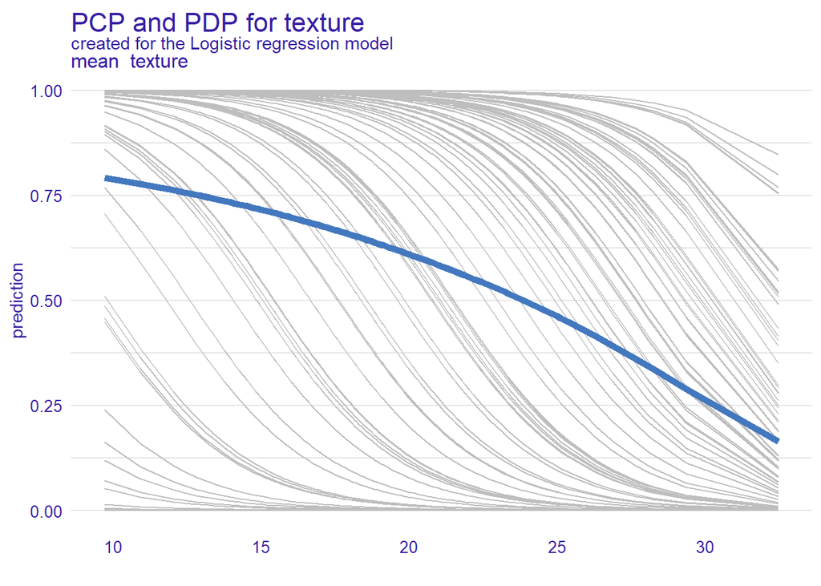

```r
pdp<- model_profile(explain_glm, "mean_texture")
plot(pdp, geom = "profiles") +
    ggtitle("PCP and PDP for texture")
```

W przypadku tekstury prawdopobieństwo nie wychodzi ponad poziom 0,8. Ma tendencję spadkową przy rosnącej teksturze. Średnia tendencja predykcji nie spada gwałtownie, tylko powoli

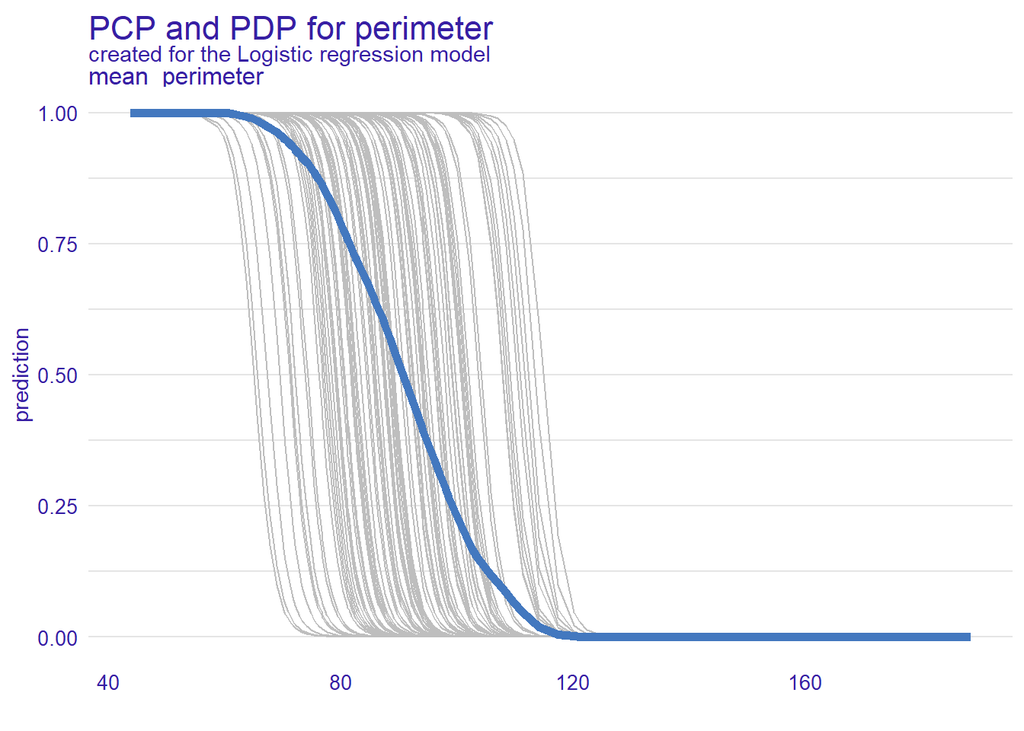

```r
pdp<- model_profile(explain_glm, "mean_perimeter")
plot(pdp, geom = "profiles") +
    ggtitle("PCP and PDP for perimeter")
```

Średnia tendencja predykcji dla obwodu jest kształtem zbliżona dla predykcji różnych obserwacji z naszego zbioru. Przy obwodzie około 60 nasze prawdopodobieństwo zaczyna regularnie spadać aż do obwodu 120 - gdzie prawdopodobieństwo jest równe 0.

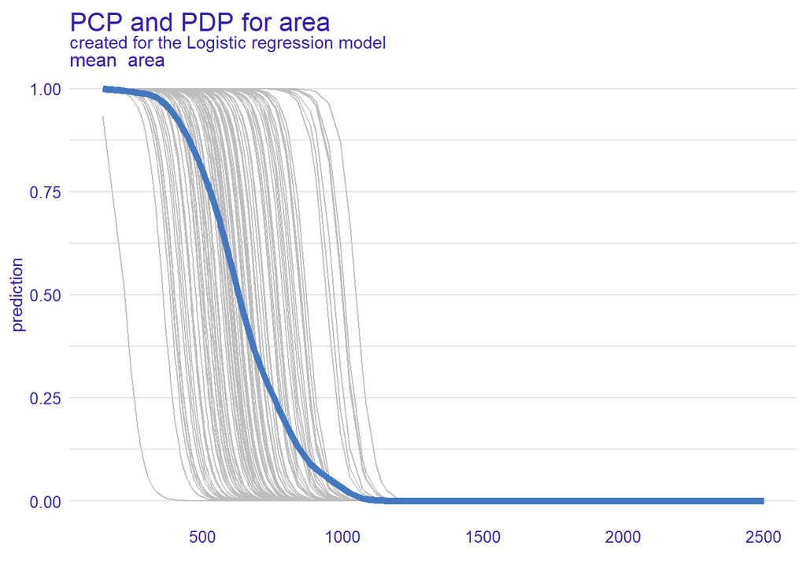

```r
pdp<- model_profile(explain_glm, "mean_area")
plot(pdp, geom = "profiles") +
    ggtitle("PCP and PDP for area")
```

Biorąc pod uwagę powierzchnię średnia predykcja również ma zbliżony kształt wtkresu do do predykcji naszych obserwacji. Pry powierzchni około 450 zaczyna spadać, aż przy około 1100 prawdopodobieństwo zachorowania wynosi 0.

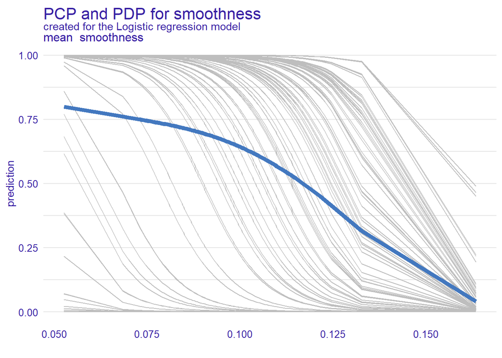

```r
pdp<- model_profile(explain_glm, "mean_smoothness")
plot(pdp, geom = "profiles") +
    ggtitle("PCP and PDP for smoothness")
```

Średnia tendencja predykcji dla gładkości również ma tendencję spadkową wraz z wzrostem wartości gładkości. Wykres PDP różni się kształtem od PCP, schodzi w dół łagodnie, gdy tendencja predykcji innych obserwacji spada dość gałtownie.